# Summary

mmWave radar sensors will change the way that we interact with appliances offering hands free interaction and automatic adjustment based on presence, location, gesturing and other movements.

[figure not shown]

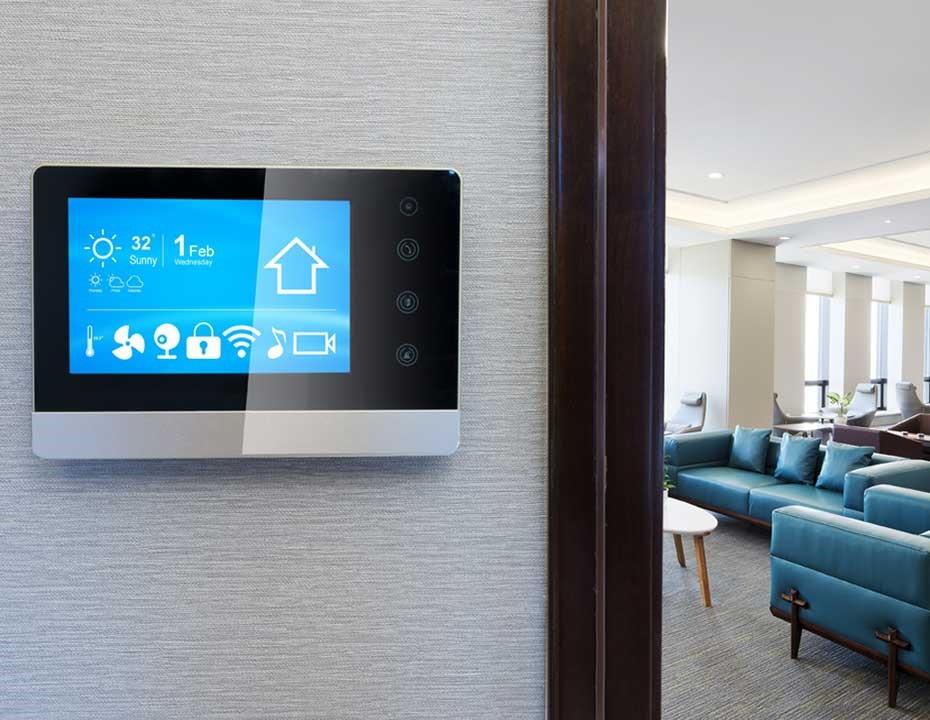

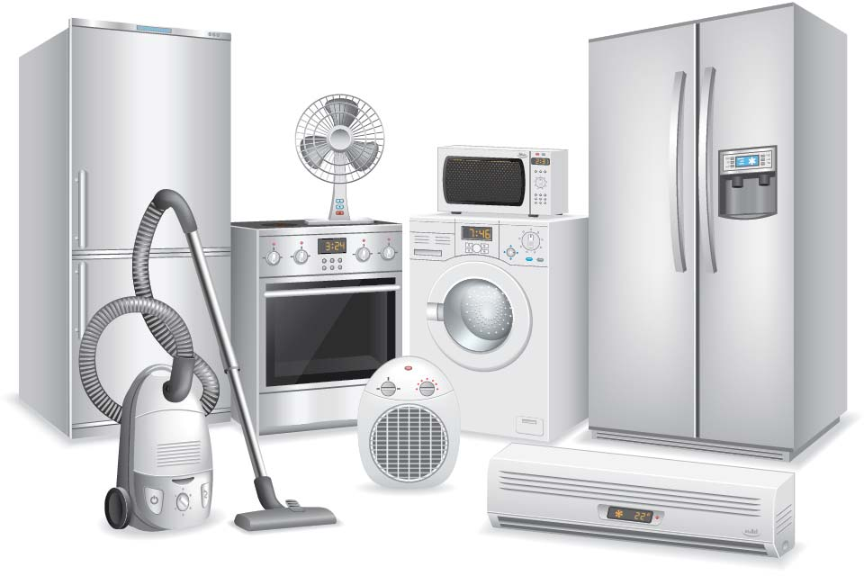

**Residential Air Conditioners**

**Thermostats**

**Washers, Dryers, Refrigerators, Freezers, and Small Home Appliances**

Recommended Devices:  
IWR6843  
IWRL6432

IWRL6432

Recommended Devices:  
IWRL6432

## Residential Air Conditioners

| Recommended devices | Key Functions | Key challenges overcome by radar |
| --- | --- | --- |
| IWR6843 IWRL6432 IWR6843AOP | - Presence detection - Motion detection - People counting - Human vs non-human classification - Localization | - False detection - Vibration calibration |

### Development Resources

**Example Projects**

- Indoor Occupancy Sensing (IWRL6432)
- 3D People Counting (IWR6843ISK, IWR6843ODS, IWR6843AOP, or IWR6843L)
- Overhead 3D People Counting (IWR6843AOP, IWR6843ODS)
- Vital Signs with People Tracking (IWR6843AOP, IWR6843ISK)

**Experiments**

- Fall Detection
- Building Occupancy Detection Using mmWave

## Thermostats

| Recommended devices | Key Functions | Key challenges overcome by radar |
| --- | --- | --- |
| IWRL6432 | - Presence detection - Motion detection - People counting - Human vs non-human classification - Localization | - False detection - Direction of motion - People Counting - Classification |

### Development Resources

**Example Projects**

- Indoor Occupancy Sensing (IWRL6432)
- Gesture Recognition(IWR6843ODS, IWR6843AOP)
- 3D People Counting (IWR6843ISK, IWR6843ODS, IWR6843AOP, or IWR6843L)

**Videos**

- [3D Occupancy Sensing Home and Office](https://training.ti.com/3d-occupancy-sensing-home-and-office)
- [People Counting mmWave Sensors Application Benefits](https://training.ti.com/people-counting-mmwave-sensors-application-benefits)

**Experiments**

- Building Occupancy Detection Using mmWave
- Very Fine Motion Detection Vs PIR

## Home Appliances

| Recommended devices | Key Functions | Key challenges overcome by radar |
| --- | --- | --- |
| IWRL6432 | - Presence detection - Motion detection - Direction of motion - Fall detection - Human vs non-human classification | - Direction of Motion - Fall detection |

### Development Resources

**Example Projects**

- Indoor Occupancy Sensing (IWRL6432)
- 3D People Counting (IWR6843ISK, IWR6843ODS, IWR6843AOP, or IWR6843L)
- Vital Signs with People Tracking (IWR6843AOP, IWR6843ISK)

**Videos**

- [3D Occupancy Sensing Home and Office](https://training.ti.com/3d-occupancy-sensing-home-and-office)
- [People Counting mmWave Sensors Application Benefits](https://training.ti.com/people-counting-mmwave-sensors-application-benefits)
- [Intelligent Fall Detection using TI mmWave Radar Sensors](https://training.ti.com/intelligent-fall-detection-using-ti-mmwave-radar-sensors)

**Experiments**

- Building Occupancy Detection Using mmWave
- Very Fine Motion Detection Vs PIR
- Fall Detection

## Certification

- [TI mmWave Radar Device Regulatory Compliance Guide](http://www.ti.com/lit/spracp3)
- TI mmWave Certification Database

## Third Party Resources

- [Designing TI mmWave radar made easier using our third-party ecosystem](https://e2e.ti.com/blogs_/b/industrial_strength/posts/ti-mmwave-radar-made-easy-with-our-third-party-ecosystem)
- [Browse third-party solutions and find the right third-party to meet your needs](https://www.ti.com/tool/MMWAVE-3P-SEARCH)